# Chapter 8 practice questions

```r
require(tidyverse)
require(rethinking)
require(dagitty)
```

## 8E1

1. Heat - bread requires both yeast and heat to rise.
2. Demographics e.g. race - white men are more likely to be hired compared to WOC with the same education, and for higher salary.
3. A more efficient engine will make a car go faster with the same amount of gas compared to a less efficient engine.

## 8E2

1. yes
2. No (or)
3. No
4. No

## 8E3

1. onion score ~ rnorm(mu,sigma) mu = a + Bheat * heat + Bmoist * moist + Bheatmoist * heat * moist
2. speed ~ rnorm(mu,sigma) mu = a + Bcyl * cyl + Binj * inj
3. belief_fromparents ~ rbinom(p) p = .7
4. intelligence ~ rnorm(mu,sigma) mu = a + Bsocial * social + Bappendage * appendage

## 8M1

blooms = bloomscold * cold bloomscold ~ rnorm(mu,sigma) mu = a + Bshade * shade + Bwater * water + Bwatershade * water * shade

Actually this feels more like a two step process: binomial is it hot or cold? If cold, then mu = the equation in the chapter

## 8M2 - see above

## 8M3

The interaction would be contingent on ravens depending on wolves for their food. If they reproduce at a lower rate than expected based on their population size when wolf population is very low, then there is a statistical interaction between raven population growth and wolf population. mu_raven pop growth = a + Bravenpop * ravenpop + Bwolfpop * wolfpop + Bravenwolf * ravenpop * wolfpop

## 8M4

```r
library(rethinking)
data(tulips)
d <- tulips
str(d)
```

```
'data.frame':   27 obs. of  4 variables:
 $ bed   : Factor w/ 3 levels "a","b","c": 1 1 1 1 1 1 1 1 1 2 ...
 $ water : int  1 1 1 2 2 2 3 3 3 1 ...
 $ shade : int  1 2 3 1 2 3 1 2 3 1 ...
 $ blooms: num  0 0 111 183.5 59.2 ...
```

```r
d$blooms_std <- d$blooms / max(d$blooms)
d$water_cent <- d$water - mean(d$water)
d$shade_cent <- d$shade - mean(d$shade)

a <- rnorm( 1e4 , 0.5 , 1 )
sum( a < 0 | a > 1 ) / length( a )
```

```
[1] 0.618
```

```r
a <- rnorm( 1e4 , 0.5 , 0.25 )
sum( a < 0 | a > 1 ) / length( a )
```

```
[1] 0.0422
```

```r
m8.4 <- quap(
alist(
blooms_std ~ dnorm( mu , sigma ) ,
mu <- a + bw*water_cent + bs*shade_cent ,
a ~ dnorm( 0.25 , 0.2 ) ,
bw ~ dnorm( .2 , 0.1 ) ,
bs ~ dnorm( -.1 , 0.05 ) ,
sigma ~ dexp( 1 )
) , data=d )

m8.5 <- quap(
alist(
blooms_std ~ dnorm( mu , sigma ) ,
mu <- a + bw*water_cent + bs*shade_cent + bws*water_cent*shade_cent ,
a ~ dnorm( 0.25 , 0.2 ) ,
bw ~ dnorm( .2 , 0.1 ) ,
bs ~ dnorm( -.1 , 0.05 ) ,
bws ~ dnorm( 0 , 0.1 ) ,
sigma ~ dexp( 1 )
) , data=d )
```

### Prior predictions

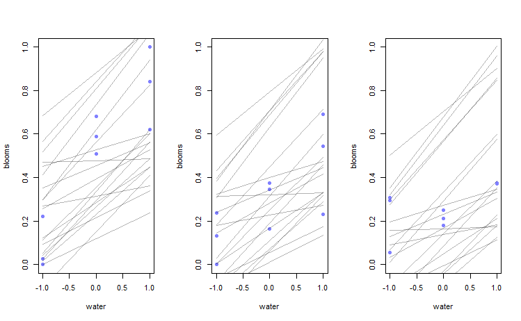

```r
set.seed(7)
prior <- extract.prior(m8.4)

par(mfrow=c(1,3)) # 3 plots in 1 row
for ( s in -1:1 ) {
idx <- which( d$shade_cent==s )
plot( d$water_cent[idx] , d$blooms_std[idx] , xlim=c(-1,1) , ylim=c(0,1) ,
xlab="water" , ylab="blooms" , pch=16 , col=rangi2 )
mu <- link( m8.4 ,post = prior, data=data.frame( shade_cent=s , water_cent=-1:1 ) )
for ( i in 1:20 ) lines( -1:1 , mu[i,] , col=col.alpha("black",0.3) )
}

set.seed(7)
prior <- extract.prior(m8.5)

par(mfrow=c(1,3)) # 3 plots in 1 row
```

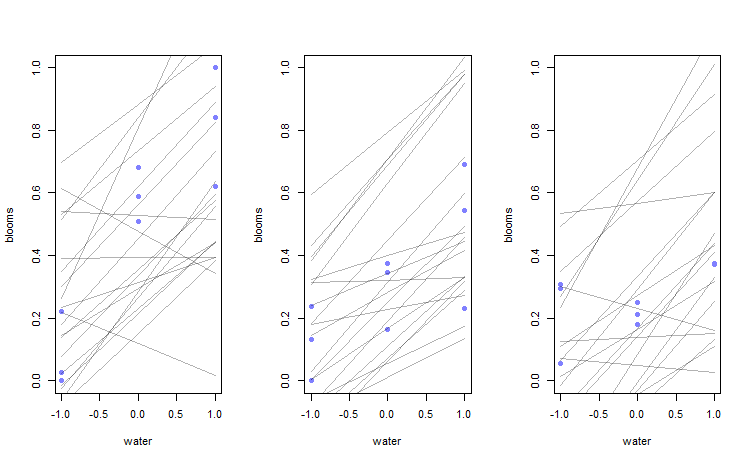

```r
for ( s in -1:1 ) {
idx <- which( d$shade_cent==s )
plot( d$water_cent[idx] , d$blooms_std[idx] , xlim=c(-1,1) , ylim=c(0,1) ,
xlab="water" , ylab="blooms" , pch=16 , col=rangi2 )
mu <- link( m8.5 ,post = prior, data=data.frame( shade_cent=s , water_cent=-1:1 ) )
for ( i in 1:20 ) lines( -1:1 , mu[i,] , col=col.alpha("black",0.3) )
}
```

### Posterior predictions

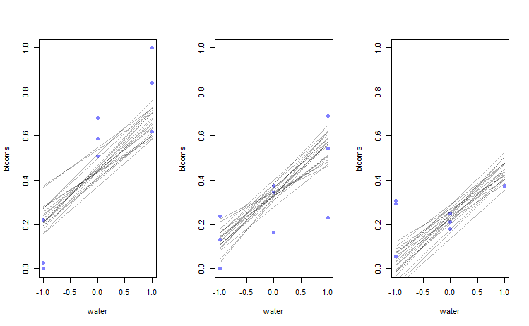

```r
par(mfrow=c(1,3)) # 3 plots in 1 row
for ( s in -1:1 ) {
idx <- which( d$shade_cent==s )
plot( d$water_cent[idx] , d$blooms_std[idx] , xlim=c(-1,1) , ylim=c(0,1) ,
xlab="water" , ylab="blooms" , pch=16 , col=rangi2 )
mu <- link( m8.4 , data=data.frame( shade_cent=s , water_cent=-1:1 ) )
for ( i in 1:20 ) lines( -1:1 , mu[i,] , col=col.alpha("black",0.3) )
}

par(mfrow=c(1,3)) # 3 plots in 1 row
```

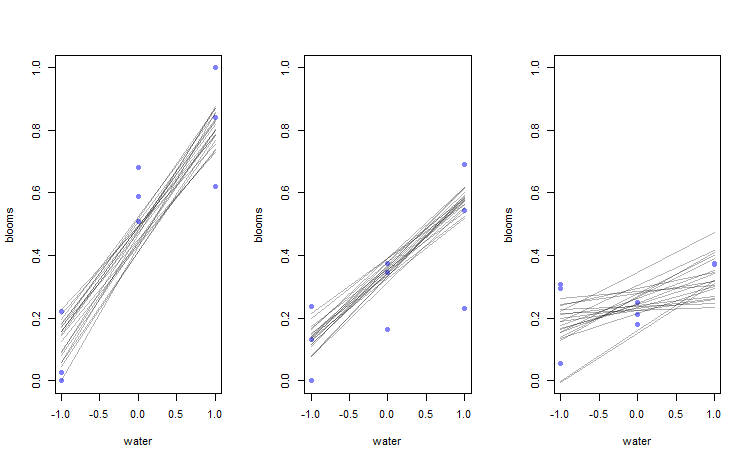

```r
for ( s in -1:1 ) {
idx <- which( d$shade_cent==s )
plot( d$water_cent[idx] , d$blooms_std[idx] , xlim=c(-1,1) , ylim=c(0,1) ,
xlab="water" , ylab="blooms" , pch=16 , col=rangi2 )
mu <- link( m8.5 , data=data.frame( shade_cent=s , water_cent=-1:1 ) )
for ( i in 1:20 ) lines( -1:1 , mu[i,] , col=col.alpha("black",0.3) )
}
```

We much more detailed information re: how fast increasing water mitigates the effects of shade, and vice versa. Seems like it would be pretty hard to constrain an interaction prior.

## 8H1

```r
library(rethinking)
data(tulips)
d <- tulips
str(d)
```

```
'data.frame':   27 obs. of  4 variables:
 $ bed   : Factor w/ 3 levels "a","b","c": 1 1 1 1 1 1 1 1 1 2 ...
 $ water : int  1 1 1 2 2 2 3 3 3 1 ...
 $ shade : int  1 2 3 1 2 3 1 2 3 1 ...
 $ blooms: num  0 0 111 183.5 59.2 ...
```

```r
d$blooms_std <- d$blooms / max(d$blooms)
d$water_cent <- d$water - mean(d$water)
d$shade_cent <- d$shade - mean(d$shade)

a <- rnorm( 1e4 , 0.5 , 1 )
sum( a < 0 | a > 1 ) / length( a )
```

```
[1] 0.6181
```

```r
a <- rnorm( 1e4 , 0.5 , 0.25 )
sum( a < 0 | a > 1 ) / length( a )
```

```
[1] 0.0418
```

```r
m8.4_bed <- quap(
alist(
blooms_std ~ dnorm( mu , sigma ) ,
mu <- a[bed] + bw*water_cent + bs*shade_cent ,
a[bed] ~ dnorm( .4 , 0.25 ) ,
bw ~ dnorm( .2 , 0.1 ) ,
bs ~ dnorm( -.1 , 0.05 ) ,
sigma ~ dexp( 1 )
) , data=d )

m8.5_bed <- quap(
alist(
blooms_std ~ dnorm( mu , sigma ) ,
mu <- a[bed] + bw*water_cent + bs*shade_cent + bws*water_cent*shade_cent ,
a[bed] ~ dnorm( .4 , 0.25 ) ,
bw ~ dnorm( .2 , 0.1 ) ,
bs ~ dnorm( -.1 , 0.05 ) ,
bws ~ dnorm( 0 , 0.1 ) ,
sigma ~ dexp( 1 )
) , data=d )
```

### Prior predictions

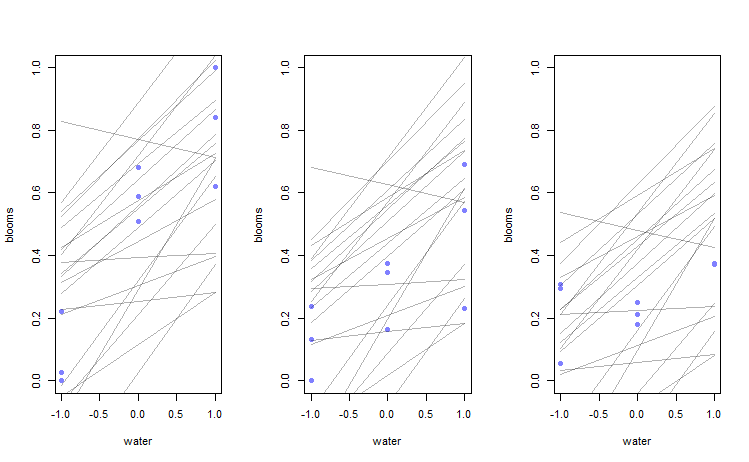

```r
set.seed(7)
prior <- extract.prior(m8.4_bed)

par(mfrow=c(1,3)) # 3 plots in 1 row
for ( s in -1:1 ) {
idx <- which( d$shade_cent==s )
plot( d$water_cent[idx] , d$blooms_std[idx] , xlim=c(-1,1) , ylim=c(0,1) ,
xlab="water" , ylab="blooms" , pch=16 , col=rangi2 )
mu <- link( m8.4_bed ,post = prior, data=data.frame( shade_cent=s , water_cent=-1:1 ,bed = 2) )
for ( i in 1:20 ) lines( -1:1 , mu[i,] , col=col.alpha("black",0.3) )
}

set.seed(7)
prior <- extract.prior(m8.5_bed)

par(mfrow=c(1,3)) # 3 plots in 1 row
```

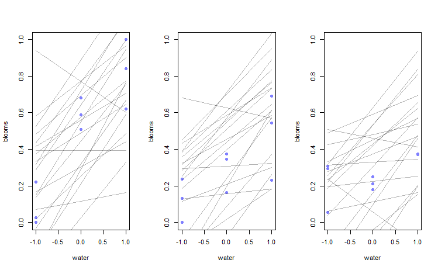

```r
for ( s in -1:1 ) {
idx <- which( d$shade_cent==s )
plot( d$water_cent[idx] , d$blooms_std[idx] , xlim=c(-1,1) , ylim=c(0,1) ,
xlab="water" , ylab="blooms" , pch=16 , col=rangi2 )
mu <- link( m8.5_bed ,post = prior, data=data.frame( shade_cent=s , water_cent=-1:1 , bed = 2) )
for ( i in 1:20 ) lines( -1:1 , mu[i,] , col=col.alpha("black",0.3) )
}
```

### Posterior predictions

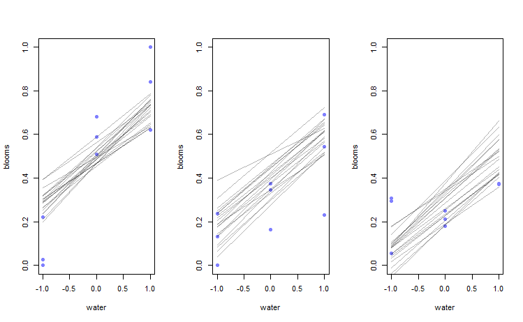

```r
par(mfrow=c(1,3)) # 3 plots in 1 row
for ( s in -1:1 ) {
idx <- which( d$shade_cent==s )
plot( d$water_cent[idx] , d$blooms_std[idx] , xlim=c(-1,1) , ylim=c(0,1) ,
xlab="water" , ylab="blooms" , pch=16 , col=rangi2 )
mu <- link( m8.4_bed , data=data.frame( shade_cent=s , water_cent=-1:1 , bed = 2) )
for ( i in 1:20 ) lines( -1:1 , mu[i,] , col=col.alpha("black",0.3) )
}

par(mfrow=c(1,3)) # 3 plots in 1 row
```

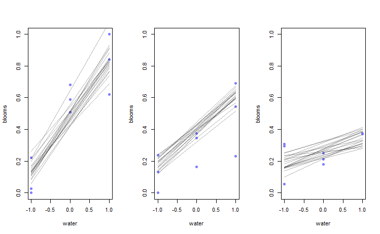

```r
for ( s in -1:1 ) {
idx <- which( d$shade_cent==s )
plot( d$water_cent[idx] , d$blooms_std[idx] , xlim=c(-1,1) , ylim=c(0,1) ,
xlab="water" , ylab="blooms" , pch=16 , col=rangi2 )
mu <- link( m8.5_bed , data=data.frame( shade_cent=s , water_cent=-1:1 , bed = 2) )
for ( i in 1:20 ) lines( -1:1 , mu[i,] , col=col.alpha("black",0.3) )
}
```

## 8H2

|  | mean | sd | 5.5% | 94.5% |
| --- | --- | --- | --- | --- |
| a[1] | 0.27 | 0.04 | 0.21 | 0.33 |
| a[2] | 0.39 | 0.04 | 0.34 | 0.45 |
| a[3] | 0.41 | 0.04 | 0.35 | 0.46 |
| bw | 0.21 | 0.02 | 0.17 | 0.25 |
| bs | -0.11 | 0.02 | -0.15 | -0.08 |
| bws | -0.13 | 0.03 | -0.18 | -0.09 |
| sigma | 0.11 | 0.01 | 0.08 | 0.13 |

## 8H3

```r
library(rethinking)
data(rugged)
d <- rugged
# make log version of outcome
d$log_gdp <- log( d$rgdppc_2000 )
# extract countries with GDP data
dd <- d[ complete.cases(d$rgdppc_2000) , ]
# rescale variables
dd$log_gdp_std <- dd$log_gdp / mean(dd$log_gdp)
dd$rugged_std <- dd$rugged / max(dd$rugged)

# make variable to index Africa (1) or not (2)
dd$cid <- ifelse( dd$cont_africa==1 , 1 , 2 )

m8.3 <- quap(
alist(
log_gdp_std ~ dnorm( mu , sigma ) ,
mu <- a[cid] + b[cid]*( rugged_std - 0.215 ) ,
a[cid] ~ dnorm( 1 , 0.1 ) ,
b[cid] ~ dnorm( 0 , 0.3 ) ,
sigma ~ dexp( 1 )
) , data=dd )

set.seed(24071847)
PSIS_m8.3 <- PSIS(m8.3,pointwise=TRUE) |> add_column(country = dd$country) |> arrange(desc(k))
```

```
Some Pareto k values are high (>0.5). Set pointwise=TRUE to inspect individual points.
```

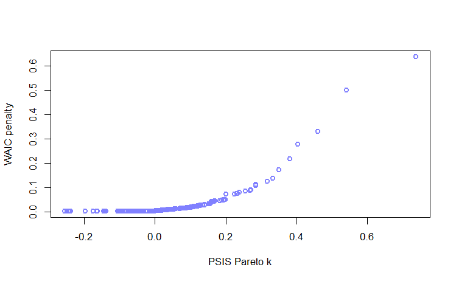

```r
set.seed(24071847)
WAIC_m8.3 <- WAIC(m8.3,pointwise=TRUE) |> add_column(country = dd$country) |> arrange(desc(penalty))
plot( PSIS_m8.3$k , WAIC_m8.3$penalty , xlab="PSIS Pareto k" ,
ylab="WAIC penalty" , col=rangi2 , lwd=2 )
```

### 8H3a

Seychelles and Switzerland have high ruggedness and high GDP while Lesotho has high ruggedness and low GDP.

### 8H3b

|  | WAIC | SE | dWAIC | dSE | pWAIC | weight |
| --- | --- | --- | --- | --- | --- | --- |
| m8.3 | -259.4 | 15.17 | 0.0 | NA | 5.0 | 1 |
| m8.3_student | -221.9 | 18.08 | 37.5 | 5.92 | 5.7 | 0 |

In my opinion the results have not substantially changed.

### 8H4

#### A. H = positive correlation language density & mean growing season length

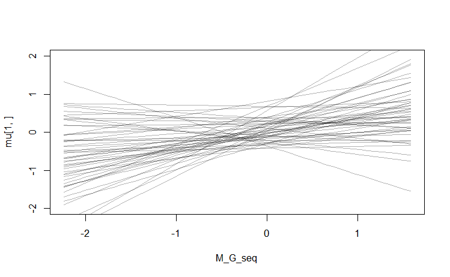

```r
data(nettle)
d <- nettle %>%
  mutate(lang.per.cap = num.lang/k.pop,
         L = log(lang.per.cap) |> standardize(),
         M_G = standardize(mean.growing.season),
         S_G = sqrt(sd.growing.season) |> standardize(),
         A = log(area/k.pop) |> standardize())

m8h4 <- quap(
  alist(
    L ~ dnorm(mu,sigma),
    mu <- a + bA * A + bM_G * M_G,
    a ~ dnorm(0,.3), # standardized predictor so a should have mu = 0
    bA ~ dnorm(.3,.5), # more area/capita should mean more languages. More area overall, without per cap scaling, meant fewer languages. Perhaps because a larger population means more cities/metropolitan exchange
    bM_G ~ dnorm(.3,.5), # longer growing season should mean more languages, but I don't want the model to be overly sure of this since it's the main effect
    sigma ~ dexp(1)
  ), data = d
)

set.seed(7)
prior <- extract.prior(m8h4)
M_G_seq <- seq(min(d$M_G),max(d$M_G),length.out = 50)
mu <- link( m8h4 ,post = prior, data=data.frame(M_G = M_G_seq,A = 0) )
plot(M_G_seq,mu[1,],ylim = c(-2,2), type = "n")
for ( i in 1:length(M_G_seq) ) lines( M_G_seq , mu[i,] , col=col.alpha("black",0.3) )
```

```r
precis(m8h4)
```

|  | mean | sd | 5.5% | 94.5% |
| --- | --- | --- | --- | --- |
| a | 0.00 | 0.08 | -0.13 | 0.13 |
| bA | 0.61 | 0.08 | 0.48 | 0.74 |
| bM_G | 0.50 | 0.08 | 0.37 | 0.63 |
| sigma | 0.70 | 0.06 | 0.61 | 0.80 |

```r
set.seed(7)

post <- link( m8h4, data=data.frame(M_G = M_G_seq,A = 0) )
plot(L~M_G, data = d)
mu <- apply(post, 2, mean)
ci <- apply(post, 2, PI)
lines(M_G_seq, mu)
```

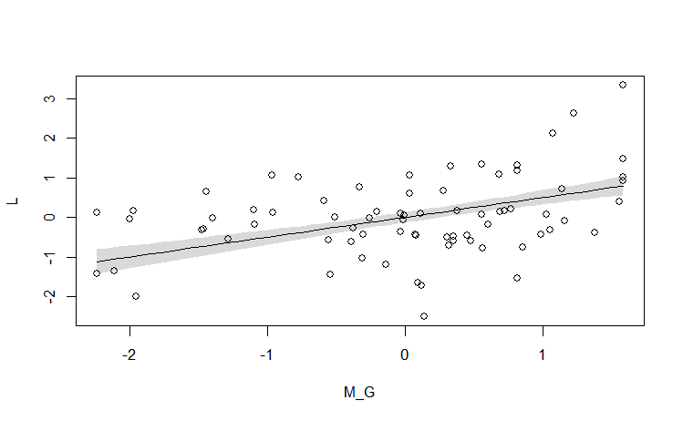

```r
shade(ci, M_G_seq)
```

#### B. H = Negative correlation between language density and standard deviation in length of growing season

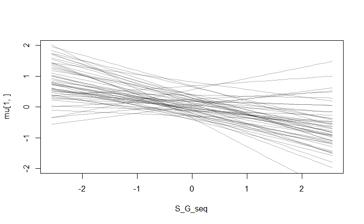

```r
data(nettle)
d <- nettle %>%
  mutate(lang.per.cap = num.lang/k.pop,
         L = log(lang.per.cap) |> standardize(),
         M_G = standardize(mean.growing.season),
         S_G = sqrt(sd.growing.season) |> standardize(),
         A = log(area/k.pop) |> standardize())

m8h4 <- quap(
  alist(
    L ~ dnorm(mu,sigma),
    mu <- a + bA * A + bS_G * S_G,
    a ~ dnorm(0,.3), # standardized predictor so a should have mu = 0
    bA ~ dnorm(.3,.3), # more area/capita should mean more languages. More area overall, without per cap scaling, meant fewer languages. Perhaps because a larger population means more cities/metropolitan exchange
    bS_G ~ dnorm(-.3,.3), # greater sd = fewer languages, but I don't want the model to be overly sure of this since it's the main effect
    sigma ~ dexp(1)
  ), data = d
)

set.seed(7)
prior <- extract.prior(m8h4)
S_G_seq <- seq(min(d$S_G),max(d$S_G),length.out = 50)
mu <- link( m8h4 ,post = prior, data=data.frame(S_G = S_G_seq,A = 0) )
plot(S_G_seq,mu[1,],ylim = c(-2,2), type = "n")
for ( i in 1:length(S_G_seq) ) lines( S_G_seq , mu[i,] , col=col.alpha("black",0.3) )
```

```r
precis(m8h4)
```

|  | mean | sd | 5.5% | 94.5% |
| --- | --- | --- | --- | --- |
| a | 0.00 | 0.09 | -0.14 | 0.14 |
| bA | 0.46 | 0.09 | 0.32 | 0.61 |
| bS_G | -0.26 | 0.09 | -0.41 | -0.12 |
| sigma | 0.82 | 0.07 | 0.71 | 0.92 |

```r
set.seed(7)

post <- link( m8h4, data=data.frame(S_G = S_G_seq,A = 0) )
plot(L~S_G, data = d)
mu <- apply(post, 2, mean)
ci <- apply(post, 2, PI)
lines(S_G_seq, mu)
```

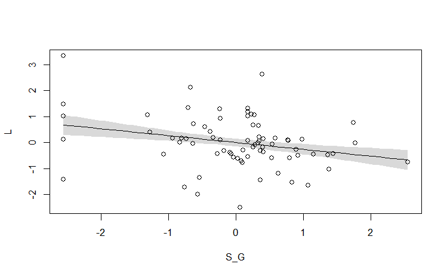

```r
shade(ci, S_G_seq)
```

#### C. H = Mean growing season and variance growing season synergistically reduce language diversity

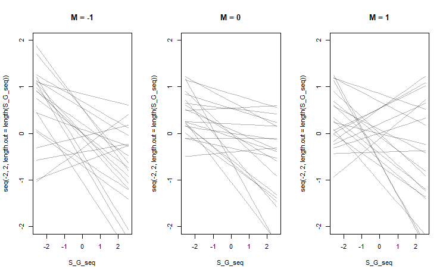

```r
data(nettle)
d <- nettle %>%
  mutate(lang.per.cap = num.lang/k.pop,
         L = log(lang.per.cap) |> standardize(),
         M_G = standardize(mean.growing.season),
         S_G = sqrt(sd.growing.season) |> standardize(),
         A = log(area/k.pop) |> standardize())

m8h4 <- quap(
  alist(
    L ~ dnorm(mu,sigma),
    mu <- a + bA * A + bS_G * S_G + bM_G * bM_G + bMS * S_G * M_G,
    a ~ dnorm(0,.4), # standardized predictor so a should have mu = 0
    bA ~ dnorm(.3,.2), # more area/capita should mean more languages. More area overall, without per cap scaling, meant fewer languages. Perhaps because a larger population means more cities/metropolitan exchange
    bS_G ~ dnorm(-.2,.2), # greater sd = fewer languages, but I don't want the model to be overly sure of this since it's the main effect
    bM_G ~ dnorm(.2,.2),
    bMS ~ dnorm(0,.2),
    sigma ~ dexp(.1)
  ), data = d
)

set.seed(NULL)
prior <- extract.prior(m8h4)
S_G_seq <- seq(min(d$S_G),max(d$S_G),length.out = 20)
m_levels <- quantile(d$M_G,c(.15,.5,.85))
par(mfrow=c(1,3)) # 3 plots in 1 row
for ( i in m_levels ) {
mu <- link( m8h4 ,post = prior, data=data.frame( M_G = i , S_G = S_G_seq, A = mean(d$A)) )
plot(S_G_seq,seq(-2,2,length.out = length(S_G_seq)),type = "n", main = paste0("M = ",round(i)))
for ( line in 1:length(S_G_seq) ) lines( S_G_seq , mu[line,] , col=col.alpha("black",0.3) )
}

set.seed(NULL)
prior <- extract.prior(m8h4)
M_G_seq <- seq(min(d$M_G),max(d$M_G),length.out = 20)
s_levels <- quantile(d$S_G,c(.15,.5,.85))
par(mfrow=c(1,3)) # 3 plots in 1 row
```

```r
for ( i in m_levels ) {
mu <- link( m8h4 ,post = prior, data=data.frame( S_G = i , M_G = M_G_seq, A = mean(d$A)) )
plot(M_G_seq,seq(-2,2,length.out = length(M_G_seq)),type = "n", main = paste0("S = ",round(i)))
for ( line in 1:length(M_G_seq) ) lines( M_G_seq , mu[line,] , col=col.alpha("black",0.3) )
}

precis(m8h4)
```

|  | mean | sd | 5.5% | 94.5% |
| --- | --- | --- | --- | --- |
| a | -0.04 | 0.11 | -0.21 | 0.14 |
| bA | 0.45 | 0.08 | 0.32 | 0.58 |
| bS_G | -0.24 | 0.08 | -0.37 | -0.11 |
| bM_G | 0.20 | 0.19 | -0.11 | 0.51 |
| bMS | -0.24 | 0.06 | -0.34 | -0.15 |
| sigma | 0.73 | 0.06 | 0.64 | 0.83 |

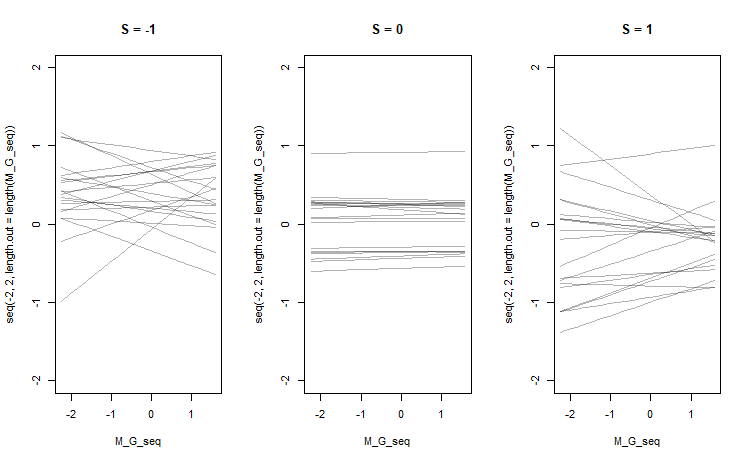

```r
S_G_seq <- seq(min(d$S_G),max(d$S_G),length.out = 20)
m_levels <- quantile(d$M_G,c(.15,.5,.85))
par(mfrow=c(1,3)) # 3 plots in 1 row
```

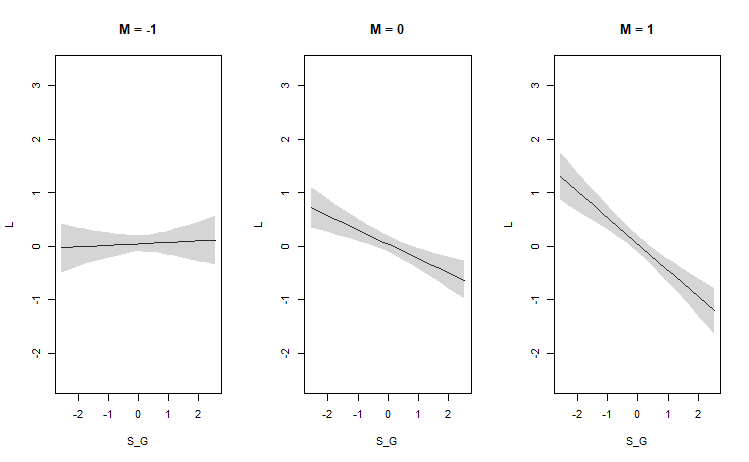

```r
for ( i in m_levels ) {
post <- link( m8h4 , data=data.frame( M_G = i , S_G = S_G_seq, A = mean(d$A)) )
plot(L~S_G,type = "n",data = d, main = paste0("M = ",round(i)))
mu <- apply(post,2,mean)
ci <- apply(post,2,PI)
for ( line in 1:length(S_G_seq) ) {
  lines( S_G_seq , mu)
  shade(ci,S_G_seq, col = col.alpha("lightgrey"))}
}

M_G_seq <- seq(min(d$M_G),max(d$M_G),length.out = 20)
s_levels <- quantile(d$S_G,c(.15,.5,.85))
par(mfrow=c(1,3)) # 3 plots in 1 row
```

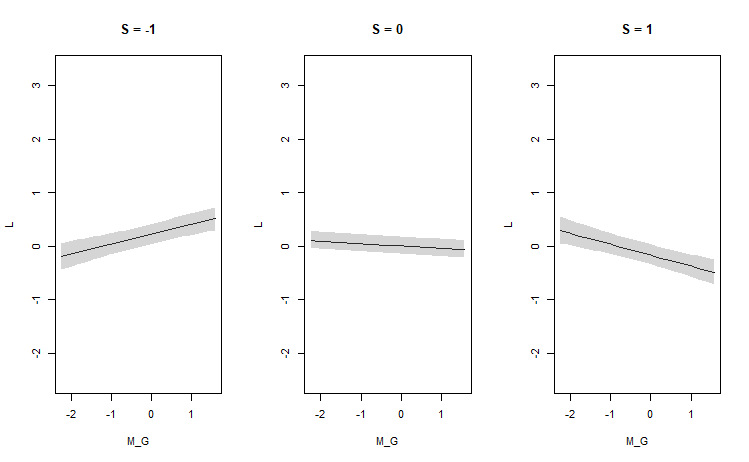

```r
for ( i in s_levels ) {
post <- link( m8h4 , data=data.frame( S_G = i , M_G = M_G_seq, A = mean(d$A)) )
plot(L~M_G,type = "n",data = d, main = paste0("S = ",round(i)))
mu <- apply(post,2,mean)
ci <- apply(post,2,PI)
for ( line in 1:length(M_G_seq) ) {
  lines( M_G_seq , mu)
  shade(ci,M_G_seq, col = col.alpha("lightgrey"))}
}
```

It seems to me that there’s good evidence that mean growing season length and variance of growing season length synergistically decrease language density.

## 8H5

```r
m8h5 %>%
  precis(depth = 2) %>%
  as_tibble(rownames = "coefficient") %>%
  select(everything(), lower_pi = '5.5%',  upper_pi = '94.5%') %>%
  mutate(type = if_else(str_starts(coefficient, "j"), "judge", "wine"),
         coefficient = fct_reorder(coefficient, mean)) %>%
  filter(coefficient != "sigma") %>%
  ggplot(aes(x = mean, y = coefficient, colour = type)) +
  geom_segment(mapping = aes(x = -1.25, xend = lower_pi, y = coefficient, yend = coefficient),
               colour = grey, linetype = "dashed", alpha = 0.7) +
  geom_vline(xintercept = 0, colour = "lavender") +
  geom_pointrange(aes(xmin = lower_pi, xmax = upper_pi),
                  size = 0.8) +
  labs(y = NULL, x = "Coefficient estimate", colour = NULL) +
  scale_colour_manual(values = c("red","purple"))# +
```

[output not shown]

## 8H6

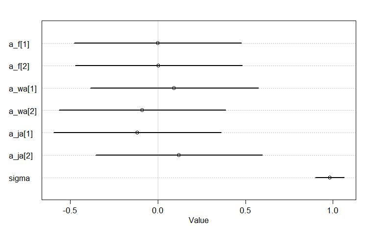

```r
data(Wines2012)
d <- Wines2012 |>
  mutate(score_std = standardize(score),
         judge_idx = as.numeric(judge),
         wine_idx = as.numeric(wine),
         flight_idx = as.numeric(flight), #1 = red, 2= white
         wine.amer_idx = if_else(wine.amer == 1,2,1),
         judge.amer_idx = if_else(judge.amer == 1,2,1))

m8h6 <- quap(
  alist(
    score_std ~ dnorm(mu,sigma),
    mu <- a_f[flight_idx] + a_wa[wine.amer_idx] + a_ja[judge.amer_idx],
    a_f[flight_idx] ~ dnorm(0,.5), # the score is standardized so these priors are pretty uninformative; but we don't have any a priori expectations about how judge should change score. As is these priors keep the score within -2, 2.
    a_wa[wine.amer_idx] ~ dnorm(0,.5), # the score is standardized so these priors are pretty uninformative; but we don't have any a priori expectations about how wine should change score.
    a_ja[judge.amer_idx] ~ dnorm(0,.5), # the score is standardized so these priors are pretty uninformative; but we don't have any a priori expectations about how wine should change score.
    sigma ~ dexp(1)
  ), data = d
)

plot(precis(m8h6, depth = 2))
```

```r
precis(m8h6, depth = 2)
```

|  | mean | sd | 5.5% | 94.5% |
| --- | --- | --- | --- | --- |
| a_f[1] | 0.00 | 0.30 | -0.48 | 0.48 |
| a_f[2] | 0.00 | 0.30 | -0.47 | 0.48 |
| a_wa[1] | 0.09 | 0.30 | -0.39 | 0.57 |
| a_wa[2] | -0.09 | 0.30 | -0.57 | 0.39 |
| a_ja[1] | -0.12 | 0.30 | -0.60 | 0.36 |
| a_ja[2] | 0.12 | 0.30 | -0.36 | 0.60 |
| sigma | 0.98 | 0.05 | 0.90 | 1.06 |

```r
post <- extract.samples(m8h6)
diff_a_f <- post$a_f[,1]-post$a_f[,2]
PI(diff_a_f)
```

```
        5%        94%
-0.2357502  0.2214644
```

```r
diff_a_wa <- post$a_wa[,1]-post$a_wa[,2]
PI(diff_a_wa)
```

```
         5%         94%
-0.04768938  0.42250397
```

```r
diff_a_ja <- post$a_ja[,1]-post$a_ja[,2]
PI(diff_a_ja)
```

```
         5%         94%
-0.47212830 -0.01102235
```

It looks like American judges give consistently higher scores than other judges.

## 8H7

```r
data(Wines2012)
d <- Wines2012 |>
  mutate(score_std = standardize(score),
         judge_idx = as.numeric(judge),
         wine_idx = as.numeric(wine),
         flight_idx = as.numeric(flight), #1 = red, 2= white
         wine.amer_idx = if_else(wine.amer == 1,2,1),
         judge.amer_idx = if_else(judge.amer == 1,2,1))

m8h6 <- quap(
  alist(
    score ~ dnorm(mu,sigma),
    mu <- a_f[flight_idx] + a_wa[wine.amer_idx] + a_ja[judge.amer_idx],
    a_f[flight_idx] ~ dnorm(0,.5), # the score is standardized so these priors are pretty uninformative; but we don't have any a priori expectations about how judge should change score. As is these priors keep the score within -2, 2.
    a_wa[wine.amer_idx] ~ dnorm(0,.5), # the score is standardized so these priors are pretty uninformative; but we don't have any a priori expectations about how wine should change score.
    a_ja[judge.amer_idx] ~ dnorm(0,.5), # the score is standardized so these priors are pretty uninformative; but we don't have any a priori expectations about how wine should change score.
    sigma ~ dexp(1)
  ), data = d
)

plot(precis(m8h6, depth = 2))
precis(m8h6, depth = 2)

post <- extract.samples(m8h6)
diff_a_f <- post$a_f[,1]-post$a_f[,2]
PI(diff_a_f)
diff_a_wa <- post$a_wa[,1]-post$a_wa[,2]
PI(diff_a_wa)
diff_a_ja <- post$a_ja[,1]-post$a_ja[,2]
PI(diff_a_ja)
```